# wallmart_pynb

### Same situation here as well.

## Q. Which of the two Genders in The data are actually spending more ?

```python
df.groupby('Gender')['Purchase'].agg(['mean', 'median', 'sum', 'count']).reset_index()
```

|  | Gender | mean | median | sum | count |
| --- | --- | --- | --- | --- | --- |
| 0 | F | 8734.565765 | 7914.0 | 1186232642 | 135809 |
| 1 | M | 9437.526040 | 8098.0 | 3909580100 | 414259 |

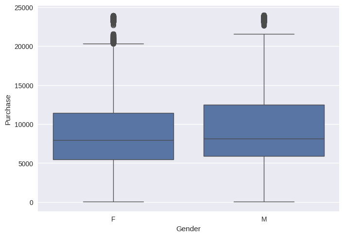

```python
sns.boxplot(data=df, x='Gender', y='Purchase')
```

## Insights

- Male users constitute approximately three times the population of female users in the dataset, which contributes to higher total revenue.
- The difference in Means of those two is around 700. Now lets test its validity.

# Inferential Analysis

### h0 : Spending Habits of males and females are same.

### ha : Spending habits of males and females are different.

assuming alpha = 0.05

```python
male_purchase = df[df['Gender'] == 'M']['Purchase']
female_purchase = df[df['Gender'] == 'F']['Purchase']
```

```python
# Sampoling Distribution

sample_size = 50
num_samples = 1000

male_sample_means = []
female_sample_means = []

for _ in range(num_samples):
  male_sample = male_purchase.sample(sample_size, replace=True)
  female_sample = female_purchase.sample(sample_size, replace=True)

  male_sample_means.append(male_sample.mean())
  female_sample_means.append(female_sample.mean())
```

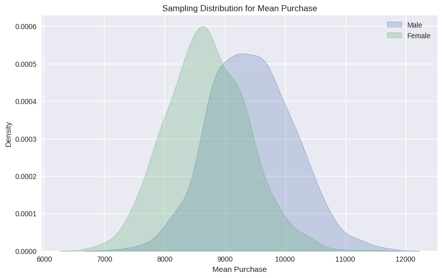

```python
plt.figure(figsize=(10,6))

sns.kdeplot(male_sample_means, label='Male', fill=True)
sns.kdeplot(female_sample_means, label='Female', fill=True)

plt.title('Sampling Distribution for Mean Purchase')
plt.xlabel('Mean Purchase')
plt.legend()
plt.show()
```

```python
# Since we are compairing two different sample means we will use two sample z test

mean_m = male_purchase.mean()
mean_f = female_purchase.mean()

n_m = len(male_purchase)
n_f = len(female_purchase)

std_m = male_purchase.std()
std_f = female_purchase.std()

se = np.sqrt((std_m**2/n_m) + (std_f**2/n_f))

z = (mean_m - mean_f)/se

print("z-value is:", z)
```

```
z-value is: 46.35824866962622
```

```python
# This is a two tailed test as there are two inequalities.

p_value = 2 * (1 - norm.cdf(abs(z)))

print("p-value is:", p_value)
```

```
p-value is: 0.0
```

## We reject the null hypothesis and we conclude that there is enough evidence to prove that Males and Females spending have statistically significant difference.

```python
def confidence_interval(data, confidence=0.95):
    mean = np.mean(data)
    std = np.std(data, ddof=1)
    n = len(data)

    z_scores = {
        0.90: 1.645,
        0.95: 1.96,
        0.99: 2.576
    }

    z = z_scores[confidence]

    margin_error = z * (std / np.sqrt(n))

    return (mean - margin_error, mean + margin_error)
```

```python
# Male
male_ci_90 = confidence_interval(male_sample_means, 0.90)
male_ci_95 = confidence_interval(male_sample_means, 0.95)
male_ci_99 = confidence_interval(male_sample_means, 0.99)

# Female
female_ci_90 = confidence_interval(female_sample_means, 0.90)
female_ci_95 = confidence_interval(female_sample_means, 0.95)
female_ci_99 = confidence_interval(female_sample_means, 0.99)

print("Male CI 90:", male_ci_90)
print("Male CI 95:", male_ci_95)
print("Male CI 99:", male_ci_99)

print("\nFemale CI 90:", female_ci_90)
print("Female CI 95:", female_ci_95)
print("Female CI 99:", female_ci_99)
```

```
Male CI 90: (np.float64(9406.395032045757), np.float64(9478.74848795424))
Male CI 95: (np.float64(9399.467573501328), np.float64(9485.67594649867))
Male CI 99: (np.float64(9385.92054345889), np.float64(9499.222976541108))

Female CI 90: (np.float64(8665.552009890493), np.float64(8735.210470109509))
Female CI 95: (np.float64(8658.882582848248), np.float64(8741.879897151754))
Female CI 99: (np.float64(8645.84014774341), np.float64(8754.92233225659))
```

```python
males['Purchase'].mean()
```

```
np.float64(9437.526040472265)
```

```python
print("Do 95% CI overlap?")
print(not (male_ci_95[1] < female_ci_95[0] or female_ci_95[1] < male_ci_95[0]))
```

```
Do 95% CI overlap?
False
```

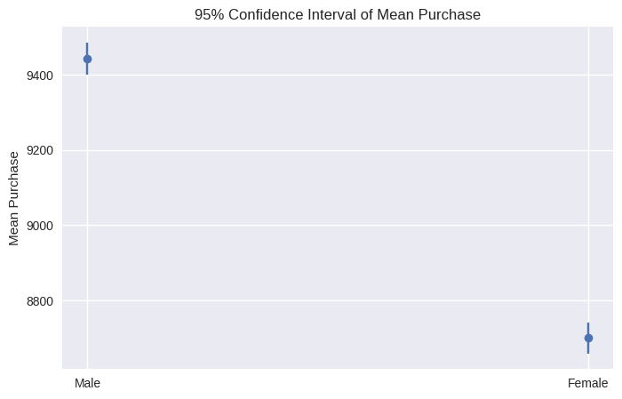

```python
plt.figure(figsize=(8,5))

plt.errorbar(
    x=['Male','Female'],
    y=[np.mean(male_sample_means), np.mean(female_sample_means)],
    yerr=[
        [np.mean(male_sample_means) - male_ci_95[0],
        np.mean(female_sample_means) - female_ci_95[0]],
        [
            male_ci_95[1] - np.mean(male_sample_means),
            female_ci_95[1] - np.mean(female_sample_means)
        ]
    ],
    fmt='o',
    capsize=5
)

plt.title('95% Confidence Interval of Mean Purchase')
plt.ylabel('Mean Purchase')
plt.show()
```